# BMIN503 Final Project: Predicting Readmissions Among Older ICU Patients

Erin Kennedy

11/24/2020

# Overview

Over the last decade, hospital readmissions have become a major focus area of healthcare policy and research, and many initiatives to understand, reduce, and prevent future readmissions have emerged. These initiatives are especially important for older adult patients, who tend to have more chronic, complex health conditions than younger patients. While these initiatives have helped begin to decrease readmissions in among Medicare patients, there is still progress to be made (Bailey et al, 2019). To date, most prediction models for hospital readmissions have focused on important clinical factors like medications, lab values, and comorbidities (Zhou et al, 2016). Newer research suggests that social determinants of health impact hospital readmissions (CDC, 2020), so the goals of this project are to describe characteristics of readmitted patients and explore factors associated with 30-day readmissions with an emphasis on social factors. This project will focus on an older adult population.

## Aims:

- Conduct an exploratory analysis comparing older adult patients who experienced 30-day readmissions to those who were not readmitted
- Identify clinical and social factors associated with readmission

This project will use MIMIC-III, an openly available dataset developed by MIT with de-identified data for approximately 60,000 intensive care unit hospitalizations including demographics, vital signs, laboratory data, medications, and unstructured notes. I would like to acknowledge this wonderful database.

[Github Repository](https://github.com/erinken/BMIN503_Final_Project)

[MIMIC-III](https://mimic.physionet.org/)

# Introduction

In 2017 alone, 3.5 million potentially preventable readmissions cost $33.7 billion (McDermott & Jiang, 2020). Implementation of readmission-risk prediction models at the point of care is an evidence-based strategy to reduce readmissions, but only 34% of hospitals enrolled in the National Hospital-to-Home quality initiative formally estimate patients’ readmission risk (Bradley et al, 2014). In 2019, the president of the American Hospital association encouraged policymakers to dedicate more resources towards understanding the discharge planning process and post-acute care trajectory (Pollack, 2019).According to a recent systematic review of readmission prediction models, most existing models have focused on important acute clinical data to predict readmission risk (Zhou et al, 2016). Recent literature suggests that social determinants of health could play an important role in hospital readmissions, and this information is starting to become more prevalent in structured EHR data (CDC, 2020). Therefore, the goal of this project is to build a prediction model to predict 30-day hospital readmissions based on both clinical and social factors.

A recent human factors study found that most patients have 1-6 different people involved in the discharge planning process, making it a truly interdisciplinary endeavor as different specialties bring different expertise to the team (Prusaczyk et al, 2019). Groups interested in building readmission prediction models should include a holistic mix of both technical and clinical experts such as biostatisticians, informaticians, data scientists, physicians, nurses, case managers, and even other ancillary clinicians like physical therapists. Since I come from a clinical background, my goal was to connect with the technical experts so my main collaborators included a biostatistician (Emily Schriver) and informaticians (Danielle Mowery, Sy Hwang, Anahita Davoudi). I would like to acknowledge all of their meaningful contributions to my project.

- Danielle Mowery: study design, MIMIC data extraction, formulating processes of data wrangling, interpretation of results
- Blanca Himes: Identifying a dataset and data extraction procedures
- Anahita Davoudi and Sy Hwang: expertise in extracting and analyzing MIMIC data, using databases
- Emily Schriver: expertise in biostatistics using R. Assisted with several packages including ggplot and elixhauser comorbidity package, and indentifying the readmissions cohort
- Gary Weissman: Expertise in wrangling MIMIC data

# Methods

The dataset used for this project was obtained from MIMIC-III, an openly available dataset of nearly 60,000 intensive care admissions including demographics, vital signs, laboratory data, medications, and notes. The database can be accessed [here](https://mimic.physionet.org/). Although there are a myriad of tables available in MIMIC, this dataset will focus on the patients, admissions, services, diagnoses, and diagnoses_icd tables. More information about the tables and schema can be found [here](https://mimic.physionet.org/mimicdata/schema/). These tables contain important demographic, comorbidity, and what types of services the patients received during their hospitalization. My variable selection is rooted in the literature for readmissions prediction models (Zhou et al 2016).

The main goal is to define a readmissions cohort and analyze the data with exploratory analysis to build a simple readmissions prediction model.

## Importing Packages (if needed)

```r
install.packages("tidyverse")
install.packages("comorbidity")
install.packages("ggplot2")
install.packages("lubridate")
install.packages("gtsummary")
install.packages("RColorBrewer")
install.packages("cowplot")
install.packages("ggpubr")
install.packages("pROC")
install.packages("dplyr")
```

## Loading Packages

```r
library(tidyverse)
library(comorbidity) # For Elixhauser comorbidity scores
library(ggplot2) # For graphs
library(lubridate) # For manipulating dates
library(gtsummary) #Summary statistics
library(RColorBrewer) # For coloring the plots
library(cowplot) # For combining multiple plots into one
library(ggpubr) # Combining multiple graphs into one figure
library(pROC) # For cross-validation
library(dplyr) # For data cleaning
```

## Reading in the Data

The MIMIC-III database offers several strategies for pulling the data including SQL, google cloud platform, and I chose to download the csv files of the tables I was interested in and pre-process the data using the dplyr package.

First, read in the necessary tables. I chose to focus on the patients, admissions, services, and ICD diagnosis tables.

```r
# admissions table
admissions <- read.csv(file = 'ADMISSIONS.csv.gz')

# selecting only variables of interest in the admissions table
admissions <- admissions %>%
  select(SUBJECT_ID, HADM_ID, ADMITTIME, DISCHTIME, ADMISSION_TYPE, ADMISSION_LOCATION, DISCHARGE_LOCATION, INSURANCE, LANGUAGE, RELIGION, MARITAL_STATUS, ETHNICITY, DIAGNOSIS, HOSPITAL_EXPIRE_FLAG)

# patients table
patients <- read.csv(file = 'PATIENTS.csv.gz')

# selecting only variables of interest in the patients table
patients <- patients %>%
  select(SUBJECT_ID, GENDER, DOB)

#services
services <- read.csv(file = 'SERVICES.csv.gz')

# selecting only variables of interest in the services table
services <- services %>%
  select(SUBJECT_ID, HADM_ID, TRANSFERTIME, CURR_SERVICE)

#diagnoses_icd
icd <- read.csv(file = 'DIAGNOSES_ICD.csv.gz')
```

## Preliminary Table Manipulation

Before I join the service table onto the main table that will be used for analysis, I’m going to collapse the services into surgical vs. non-surgical for my analysis. The list of service lines is very long so please see the [data dictionary](https://mimic.physionet.org/mimictables/services/) for more information on these codes.

Although I chose a slightly different method, I found this stack overflow [thread](https://stackoverflow.com/questions/44508585/calculate-readmission-rate) helpful for collapsing categorical variables.

```r
# First, removing duplicates in the service dataset to ensure that only the admission service is documented (because we want to know if the patient was addmitted for a surgery or not)
sum(duplicated(services$HADM_ID))
```

```
## [1] 14417
```

```r
services<- services %>%
  #group_by(HADM_ID, TRANSFERTIME) %>%
  distinct(HADM_ID, .keep_all=TRUE)
sum(duplicated(services$HADM_ID))
```

```
## [1] 0
```

```r
# Next dichotomizing the service categories and ensuring that no values are missing
sum(is.na(services$CURR_SERVICE))
```

```
## [1] 0
```

```r
table(services$CURR_SERVICE)
```

```
##
##  CMED CSURG  DENT   ENT    GU   GYN   MED    NB   NBB  NMED NSURG   OBS  OMED ORTHO PSURG  SURG TRAUM TSURG VSURG
##  7551  4894     3   187   334   194 20783  7806   290  2275  3426    47   973   667   202  3990  3030  1097  1177
```

```r
surgical <- c("CSURG", "NSURG", "ORTHO", "PSURG", "SURG", "TSURG", "VSURG")
non_surgical <-c("CMED", "DENT", "ENT", "GU", "GYN", "MED", "NB", "NBB", "NMED", "OBS", "OMED", "PSYCH", "TRAUM")

services <- services%>%
  mutate(service = case_when(
    CURR_SERVICE %in% non_surgical ~ "NON-SURGICAL",
    CURR_SERVICE %in% surgical ~ "SURGICAL"
  )) %>% select(HADM_ID, service)

sum(is.na(services$service))
```

```
## [1] 0
```

```r
table(services$service)
```

```
##
## NON-SURGICAL     SURGICAL
##        43473        15453
```

I am also going to clean the ICD codes and calculate Elixhauser comorbidity scores . I figured out how to manipulate the rows using this [Stack Overflow Thread](https://stackoverflow.com/questions/49225596/merge-multiple-rows-into-one-using-r). I used the [comorbidity package](https://cran.r-project.org/web/packages/comorbidity/comorbidity.pdf) to create the scores. I chose to use the Elixhauser score because it outperforms the Charlson score in readmission models (Menendez 2014)

```r
# Manipulating the ICD dataset to put all ICD codes for a patient into one row
icd <- icd %>%
  group_by(HADM_ID) %>%
  summarize(ICD9_CODE = paste(ICD9_CODE,collapse=" "))
#Creating the dataframe with the scoring
comorbidities <- comorbidity(x = icd, id = "HADM_ID", code="ICD9_CODE", score = "elixhauser", assign0=FALSE, icd= "icd9")

# Selecting only the HADM_ID and the windex_ahrq which has the elixhauser groupings
comorbidities <- comorbidities %>%
  rename(elixhauser_categories=windex_ahrq) %>%
  select(HADM_ID, elixhauser_categories)

# Removing the icd table to clean up the environment
rm(icd)
```

## Joining the Tables

Merging the tables into one main MIMIC dataset

```r
# Joining the Admission and patients table into the larger mimic table on the SUBJECT_ID
mimic <- inner_join(patients, admissions, by = "SUBJECT_ID")

#Joining the services table onto the mimic table on the HADM_ID
mimic <- inner_join(mimic, services, by = "HADM_ID")

# Joining the comorbidities table onto the mimic table on the HADM_ID
mimic<- inner_join(mimic, comorbidities, by = "HADM_ID")
```

## Cohort Identification

Next, identifying patients discharged ALIVE

```r
#code to filter out those with disposition death and non-newborn
mimic <- mimic %>%
  filter(HOSPITAL_EXPIRE_FLAG == 0 & DISCHARGE_LOCATION != "DEAD/EXPIRED")

#confirming exclusion of patients who died in the hospital
table(mimic$DISCHARGE_LOCATION)
```

```
##
## DISC-TRAN CANCER/CHLDRN H   DISC-TRAN TO FEDERAL HC  DISCH-TRAN TO PSYCH HOSP                      HOME          HOME HEALTH CARE HOME WITH HOME IV PROVIDR              HOSPICE-HOME  HOSPICE-MEDICAL FACILITY                       ICF LEFT AGAINST MEDICAL ADVI   LONG TERM CARE HOSPITAL            …
##                       669                        11                       446                     18933                     13953                        67                       402                       153                        47                       364                      2304            …
##  SNF-MEDICAID ONLY CERTIF
##                         1
```

```r
#extra step to confirm that the hospital expire flag = 0
table(mimic$HOSPITAL_EXPIRE_FLAG)
```

```
##
##     0
## 53073
```

```r
unique(admissions$DISCHARGE_LOCATION)
```

```
##  [1] "DISC-TRAN CANCER/CHLDRN H" "HOME HEALTH CARE"          "HOME"                      "DEAD/EXPIRED"              "REHAB/DISTINCT PART HOSP"  "LONG TERM CARE HOSPITAL"   "DISC-TRAN TO FEDERAL HC"   "SNF"                       "SHORT TERM HOSPITAL"       "HOSPICE-MEDICAL FACILITY"  "HOME WITH H…
## [15] "OTHER FACILITY"            "ICF"                       "SNF-MEDICAID ONLY CERTIF"
```

```r
unique(admissions$hospital_expire_flag)
```

Next, calculating age and excluding those over 90 because their DOBs have been shifted, as well as those <18. For creating the age variable I found this [Stack Overflow Thread](https://stackoverflow.com/questions/31126726/efficient-and-accurate-age-calculation-in-years-months-or-weeks-in-r-given-b) very helpful. I also created a length of stay (in days) variable in this step.

```r
# Clearing dataframes we no longer need
rm(admissions)
rm(patients)
rm(services)
rm(comorbidities)

head(mimic$DOB)
```

```
## [1] "2075-03-13 00:00:00" "2075-03-13 00:00:00" "2075-03-13 00:00:00" "2090-03-15 00:00:00" "2078-03-06 00:00:00" "2078-03-06 00:00:00"
```

```r
# converting the dob, admittime, and dischargetime to dates
mimic <- mimic %>%
  mutate(DOB = as.Date(DOB, format = "%Y-%m-%d")) %>%
  mutate(ADMITTIME = as.Date(ADMITTIME, format = "%Y-%m-%d")) %>%
  mutate(DISCHTIME = as.Date(DISCHTIME, format = "%Y-%m-%d"))

head(mimic$DOB)
```

```
## [1] "2075-03-13" "2075-03-13" "2075-03-13" "2090-03-15" "2078-03-06" "2078-03-06"
```

```r
# checking to make sure the conversion worked
class(mimic$DOB)
```

```
## [1] "Date"
```

```r
class(mimic$ADMITTIME)
```

```
## [1] "Date"
```

```r
class(mimic$DISCHTIME)
```

```
## [1] "Date"
```

```r
# calculating age and length of stay
mimic <- mimic %>%
  mutate(AGE = as.period(interval(start = DOB, end = ADMITTIME))$year) %>%
  mutate(LOS = as.period(interval(start = ADMITTIME, end = DISCHTIME))$day)

summary(mimic$AGE)
```

```
##    Min. 1st Qu.  Median    Mean 3rd Qu.    Max.
##    0.00   41.00   60.00   61.31   74.00  311.00
```

```r
summary(mimic$LOS)
```

```
##    Min. 1st Qu.  Median    Mean 3rd Qu.    Max.
##   0.000   4.000   6.000   8.034  11.000  30.000
```

```r
#Checking to see the number of patients <55 or >89
sum(mimic$AGE > 90)
```

```
## [1] 2064
```

```r
sum(mimic$AGE < 55)
```

```
## [1] 21722
```

```r
#filtering age to only those who are 55-90 (a limitation of the study with the upper age limit). Now we can see there are substantially less patients in the dataset
mimic <- mimic %>%
  filter(between(AGE, 55, 89))

# Checking to make sure age is properly filtered
summary(mimic$AGE)
```

```
##    Min. 1st Qu.  Median    Mean 3rd Qu.    Max.
##   55.00   63.00   70.00   70.55   78.00   89.00
```

Next, we will sort the dataframe by patient ID and ADMITTIME to determine the times to readmission and create a flag to identify the 30-day readmission cohort.

**How I created time_to_readmission:** new variable subtracts NEXT admission date minus CURRENT discharge date  
**How I created readmitted_30:** new variable coded as 1 (readmission within 30 days) or 0 (no readmission or future admission beyond 30 days). Same concepts were used to create the 7-day and 14-day readmissions variables.

*Note: I also created 7- and 14- day readmissions variables for future analysis*

```r
mimic <- mimic %>%
  arrange(SUBJECT_ID, ADMITTIME, by_group = TRUE) %>%
  group_by(SUBJECT_ID) %>%
  mutate(count=1:n()) %>% #added a counter variable so I can see how many times each patient was hospitalized
  mutate(time_to_readmission = as.numeric(lead(ADMITTIME, 1) - DISCHTIME)) %>%
  mutate(readmitted_30 = if_else(time_to_readmission<=30, 1,0)) %>%
  mutate(readmitted_14 = if_else(time_to_readmission<=14, 1,0)) %>%
  mutate(readmitted_7 = if_else(time_to_readmission<=7, 1,0))

table(mimic$count)
```

```
##
##     1     2     3     4     5     6     7     8     9    10    11    12    13    14    15    16    17    18    19    20    21    22    23    24
## 22350  4296  1343   569   275   139    88    64    40    31    24    19    12     8     7     6     4     3     3     2     1     1     1     1
```

```r
# Converting all of the NA's to 0, because those patients only had 1 admission in the entire dataset and weren't captured by that mutate command
mimic[["readmitted_30"]][is.na(mimic[["readmitted_30"]])] <- 0
mimic[["readmitted_14"]][is.na(mimic[["readmitted_14"]])] <- 0
mimic[["readmitted_7"]][is.na(mimic[["readmitted_7"]])] <- 0

#Checking to see the number of readmissions in each group
table(mimic$readmitted_30)
```

```
##
##     0     1
## 27469  1818
```

```r
table(mimic$readmitted_14)
```

```
##
##     0     1
## 28136  1151
```

```r
table(mimic$readmitted_7)
```

```
##
##     0     1
## 28583   704
```

```r
#Changing readmitted_30 to factor since this will be important
mimic$readmitted_30 <- factor(mimic$readmitted_30, levels = c(0,1), labels = c("Non-Readmission", "Readmission"))

#Creating a new readmission categories variable for nice visualizations in the exploratory analysis part
mimic$readmission_cat <-cut(mimic$time_to_readmission, c(-Inf,7,14,30))

#Checking to see if this new categorical variable aligns with
table(mimic$readmission_cat)
```

```
##
## (-Inf,7]   (7,14]  (14,30]
##      704      447      667
```

## Additional Cleaning

Next, collapsing the ethnicity categories, religion categories, marriage categories, and discharge disposition categories.Note that results are set to false in order to save space but you can run the chunk to make sure the categories are error-free. The categorization methods were based in the literature as well as frequencies of each group. As much as we would like to keep all categories, some groups only had 1 patient. These are the collapsing steps that I chose to pursue:

- Ethnicity categories: ASIAN (any group containing “Asian”), BLACK (any group containing “Black”), HISPANIC (any group containing “Hispanic”), WHITE (any group containing “White”), and OTHER/UNKNOWN (combination of all other groups including multi-race, Carribean island, Portuguese, Middle Eastern, South American, American Indian/Alaska Native, Native Hawaiian or other Pacific Islander, and other variables to indicate unknown status)
- Religious categories: JEWISH (any group containing “Jewish”), BUDDHIST (any group containing “Buddhist”), CATHOLIC (any group containing “Catholic”), HINDU (any group containing “Hindu”), MUSLIM (any group containing “Muslim”), Christian (Christian scientist, Episcopalian, Baptist, Lutheran, Protestant Quaker, Methodist), OTHER/UNKNOWN (“NOT SPECIFIED”, “UNOBTAINABLE”, “7TH DAY ADVENTIST”, “OTHER”, “HEBREW”, “ROMANIAN EAST. ORTH”, “GREEK ORTHODOX”, “UNITARIAN-UNIVERSALIST”, “JEHOVAH’S WITNESS”, “Unknown”)
- Marital Status Categories: MARRIED/LIFE PARTNER (Married or Life Partner), NOT MARRIED (“DIVORCED”, “SEPARATED”, “SINGLE”, “UNKNOWN (DEFAULT)”, “WIDOWED”)
- Discharge Location: HOME (Home), HHC- home health care (“HOME HEALTH CARE”, “HOME WITH HOME IV PROVIDR”), TRANSFER(“DISC-TRAN CANCER/CHLDRN H”, “DISC-TRAN TO FEDERAL HC”, “DISCH-TRAN TO PSYCH HOSP”), HOSPICE (“HOSPICE-HOME”, “HOSPICE-MEDICAL FACILITY”), AMA- against medical advice, SNF- skilled nursing facility(“SNF”, “SNF-MEDICAID ONLY CERTIF”), IRF- inpatient rehabilitation facility (“REHAB/DISTINCT PART HOSP”), OTHER (“ICF”, “LONG TERM CARE HOSPITAL”, “OTHER FACILITY”, “SHORT TERM HOSPITAL”)

```r
# Starting with Ethnicity
table(mimic$ETHNICITY) # Before
sum(is.na(mimic$ETHNICITY)) # Checking for missing values- none

unknown_ethnicity <- c("UNKNOWN/NOT SPECIFIED", "PATIENT DECLINED TO ANSWER", "UNABLE TO OBTAIN", "OTHER", "MULTI RACE ETHNICITY", "UNKNOWN/NOT SPECIFIED", "CARIBBEAN ISLAND", "PORTUGUESE", "MIDDLE EASTERN", "SOUTH AMERICAN", "AMERICAN INDIAN/ALASKA NATIVE", "AMERICAN INDIAN/ALASKA NATIVE FEDERALLY RECOGNIZED TRIBE", "NATIVE HAWAIIAN OR OTHER PACIFIC ISLANDER") # Making a list of the unknowns that we can combine

mimic <- mimic %>%
  mutate(ethnicity_categories = case_when(
    str_detect(ETHNICITY, "^ASIAN") ~ "ASIAN",
    str_detect(ETHNICITY, "^BLACK") ~ "BLACK",
    str_detect(ETHNICITY, "^HISPANIC") ~ "HISPANIC",
    str_detect(ETHNICITY, "^WHITE") ~ "WHITE",
    ETHNICITY %in% unknown_ethnicity ~ "OTHER/UNKNOWN"
  ))

#Changing to factor to make analysis easier
mimic$ethnicity_categories <- as.factor(mimic$ethnicity_categories)

table(mimic$ethnicity_categories) # After
sum(is.na(mimic$ethnicity_categories)) # No missing values

# Next, Religion
table(mimic$RELIGION) # Before
sum(is.na(mimic$RELIGION))

christian <- c("CHRISTIAN SCIENTIST", "EPISCOPALIAN", "BAPTIST", "LUTHERAN", "PROTESTANT QUAKER", "METHODIST")
unknown_religion <-c("NOT SPECIFIED", "UNOBTAINABLE", "7TH DAY ADVENTIST", "OTHER", "HEBREW", "ROMANIAN EAST. ORTH", "GREEK ORTHODOX", "UNITARIAN-UNIVERSALIST", "JEHOVAH'S WITNESS", "Unknown")

mimic <-mimic %>%
  mutate(religion_categories = case_when(
    str_detect(RELIGION, "^JEWISH") ~ "JEWISH",
    str_detect(RELIGION, "^BUDDHIST") ~ "BUDDHIST",
    str_detect(RELIGION, "^CATHOLIC") ~ "CATHOLIC",
    str_detect(RELIGION, "^HINDU") ~ "HINDU",
    str_detect(RELIGION, "^MUSLIM") ~ "MUSLIM",
    RELIGION %in% christian ~ "CHRISTIAN",
    RELIGION %in% unknown_religion ~ "OTHER/UNKNOWN",
    TRUE ~ "OTHER/UNKNOWN"
  ))

table(mimic$religion_categories) # After
sum(is.na(mimic$religion_categories)) # No missing values

# Marital status categories - This is more for the regression
table(mimic$MARITAL_STATUS) #before
sum(is.na(mimic$MARITAL_STATUS)) #Looking for missing values

married <- c("MARRIED", "LIFE PARTNER")
not_married <- c(" ", "", "DIVORCED", "SEPARATED", "SINGLE", "UNKNOWN (DEFAULT)", "WIDOWED")

mimic <- mimic %>%
  mutate(marital_dichotomous = case_when(
    MARITAL_STATUS %in% married ~ "MARRIED/LIFE PARTNER",
    MARITAL_STATUS %in% not_married ~ "NOT MARRIED"
  ))

table(mimic$marital_dichotomous) # After
sum(is.na(mimic$marital_dichotomous)) # No Missing values

# Discharge disposition categories
table(mimic$DISCHARGE_LOCATION)
sum(is.na(mimic$DISCHARGE_LOCATION))

home <- c("HOME")
home_health <- c("HOME HEALTH CARE", "HOME WITH HOME IV PROVIDR")
transfer <- c("DISC-TRAN CANCER/CHLDRN H", "DISC-TRAN TO FEDERAL HC", "DISCH-TRAN TO PSYCH HOSP")
hospice <- c("HOSPICE-HOME", "HOSPICE-MEDICAL FACILITY")
ama <- c("LEFT AGAINST MEDICAL ADVI")
snf <- c("SNF", "SNF-MEDICAID ONLY CERTIF")
rehab<- c("REHAB/DISTINCT PART HOSP")
other_facility <- c("ICF", "LONG TERM CARE HOSPITAL", "OTHER FACILITY", "SHORT TERM HOSPITAL")

mimic <- mimic %>%
  mutate(discharge_categories = case_when(
    DISCHARGE_LOCATION %in% home ~ "HOME",
    DISCHARGE_LOCATION %in% home_health ~ "HHC",
    DISCHARGE_LOCATION %in% transfer ~ "TRANSFER",
    DISCHARGE_LOCATION %in% hospice ~ "HOSPICE",
    DISCHARGE_LOCATION %in% ama ~ "AMA",
    DISCHARGE_LOCATION %in% snf ~ "SNF",
    DISCHARGE_LOCATION %in% rehab ~ "IRF",
    DISCHARGE_LOCATION %in% other_facility ~ "OTHER",
  ))

table(mimic$discharge_categories)
sum(is.na(mimic$discharge_categories))
```

## Filtering to Index Admission

The goal of this study is to determine factors in the FIRST hospitalization that could be predictive of future readmissions, which is why we excluded the later hospitalizations.

```r
mimic <- mimic %>%
  filter(count<2) %>%
  ungroup()
```

Picking the Color Palate– These tell me which colors to select when I make my graphs

```r
colors <- brewer.pal(9, "RdBu")
```

## Dichotomizing Variables

**It is common for categorical and continuous variables to be collapsed into smaller categories or dichotomous variables to improve model performance. Although there is inherent risk of bias in dichotomization, I chose to use data-driven methods to try to achieve more balance between groups. After initial review I chose to explore this path with variables in the dataset**

Note that the results are hidden to save space but you can run the chunk to make sure the results are error-free

- Admission categories dichotomized to ELECTIVE (elective) vs. EMERGENCY/URGENT(emergency/urgent)
- Discharge disposition dichotomized to HOME (home health care or home) vs. NON-HOME (against medical advice, hospice, other, rehabilitation, skilled nursing facility, transfer)
- Insurance categorized to 3 levels: Private (private), Self pay(Self Pay), and Public (Government, Medicaid, Medicare)
- Ethnicity dichotomized to WHITE (white) vs. NON-WHITE (ASIAN, BLACK, HISPANIC, OTHER/UNKNOWN)
- Continuous age variable dichotomized at the median to ages 55-70 and 71-89
- Continuous length of stay variable dichotomized at the median to 0-7 days and 8 or more days

```r
# Admission Type
table(mimic$ADMISSION_TYPE)
emergency_other <- c("EMERGENCY", "URGENT")

mimic <- mimic %>%
  mutate(admission_dichotomous = case_when(
    str_detect(ADMISSION_TYPE, "^ELECTIVE") ~ "ELECTIVE",
    ADMISSION_TYPE %in% emergency_other ~ "EMERGENCY/URGENT"
  ))
table(mimic$admission_dichotomous)
sum(is.na(mimic$admission_dichotomous)) # No missing values

# Discharge Disposition
table(mimic$discharge_categories)
non_home <- c("AMA", "HOSPICE", "OTHER", "IRF", "SNF", "TRANSFER")
home_discharge<-c("HHC", "HOME")

mimic <- mimic %>%
  mutate(discharge_dichotomous = case_when(
    discharge_categories %in% home_discharge ~ "HOME",
    discharge_categories %in% non_home ~ "NON-HOME"
  ))
table(mimic$discharge_dichotomous)
sum(is.na(mimic$discharge_dichotomous)) # no missing values!

# Insurance
table(mimic$INSURANCE)
gov_insurance <- c("Government", "Medicaid", "Medicare")

mimic <- mimic %>%
  mutate(insurance_categories = case_when(
    str_detect(INSURANCE, "^Private") ~ "Private",
    str_detect(INSURANCE, "Self Pay") ~ "Self Pay",
    INSURANCE %in% gov_insurance ~ "Public"
  ))
table(mimic$insurance_categories)
sum(is.na(mimic$insurance_categories)) # No missing values

# Ethnicity
table(mimic$ethnicity_categories)
non_white <- c("ASIAN", "BLACK", "HISPANIC", "OTHER/UNKNOWN")

mimic <- mimic %>%
  mutate(ethnicity_dichotomous = case_when(
    str_detect(ethnicity_categories, "^WHITE") ~ "WHITE",
    ethnicity_categories %in% non_white ~ "NON-WHITE"
  ))
mimic$ethnicity_dichotomous<- as.factor(mimic$ethnicity_dichotomous)

table(mimic$ethnicity_dichotomous)
sum(is.na(mimic$ethnicity_dichotomous)) # No missing values

# Elixhauser
fct_count(mimic$elixhauser_categories)

mimic$elixhauser_dichotomous<-fct_collapse(mimic$elixhauser_categories,
                   zero_or_less = c("<0", "0"),
                   one_or_more = c("1-4", ">=5"))
fct_count(mimic$elixhauser_dichotomous)

# Age - Splitting at the median and mean (both 70)
summary(mimic$AGE)
mimic$age_dichotomous <-cut(mimic$AGE, c(54,70,89))

table(mimic$age_dichotomous)
sum(is.na(mimic$age_dichotomous)) # No missing values

# LOS - dichotomizing at the median (7 days)
summary(mimic$LOS)
mimic$los_dichotomous <- cut(mimic$LOS, c(-Inf, 7, 30))
table(mimic$los_dichotomous)
sum(is.na(mimic$los_dichotomous)) # no missing values
```

## Writing Final Dataset to file- Necessary if you want to use the preliminary_statistics file

```r
write.csv(mimic, "mimic.csv", row.names=TRUE)
```

# Results

## Summary Statistics- Overall

This section contains descriptive statistics for the overall cohort (See details on the [gtsummary package](http://www.danieldsjoberg.com/gtsummary/)). This chunk begins with a summary table and then visualizations for the overall sample. Not all of these variables are included in the logistic model.

The final sample had 22,350 unique patients. It was 57% male, 75% white, mean age 70 years old (range 55-89), majority insured by Medicare (66%), 53% were Catholic or Christian religion, and 55% were married. In terms of clinical characteristics, the cohort was 64% non-surgical, 76% were admitted through the emergency department, 82% had Elixhauser Comorbidity scores (ARHQ) of 0 or less, average length of stay was 7 days. Discharge disposition was 31% home health care, 23% home, 20% skilled nursing facility, 16% inpatient rehabilitation facility, 6% other, 1.8% transfer to another acute facility, 1.3% hospice, and 0.3% against medical advice. Only 1,083 patients were readmitted in 30 days or less (4.8% so the cohort is skewed towards the non-readmissions cohort). Among those who experienced readmissions, 41% occured within 7 days, 24% occurred within 8-14 days, and 34% occured within 15-30 days.

```r
mimic_summary <- mimic %>%
  select(GENDER, AGE, INSURANCE, religion_categories, MARITAL_STATUS, ethnicity_categories, ADMISSION_TYPE, service, elixhauser_categories, LOS, discharge_categories, time_to_readmission, readmission_cat, readmitted_30)

table1<- tbl_summary(
  mimic_summary,
  missing = "no",
) %>%
  modify_header(label = "**Variable**") %>%
  bold_labels()
table1
```

| **Variable** | **N = 22,350**<sup>1</sup> |
| --- | --- |
| GENDER |  |
| F | 9,590 (43%) |
| M | 12,760 (57%) |
| AGE | 70 (62, 78) |
| INSURANCE |  |
| Government | 316 (1.4%) |
| Medicaid | 1,031 (4.6%) |
| Medicare | 14,745 (66%) |
| Private | 6,164 (28%) |
| Self Pay | 94 (0.4%) |
| religion_categories |  |
| BUDDHIST | 78 (0.3%) |
| CATHOLIC | 8,504 (38%) |
| CHRISTIAN | 3,448 (15%) |
| HINDU | 32 (0.1%) |
| JEWISH | 2,114 (9.5%) |
| MUSLIM | 59 (0.3%) |
| OTHER/UNKNOWN | 8,115 (36%) |
| MARITAL_STATUS |  |
|  | 921 (4.1%) |
| DIVORCED | 1,481 (6.6%) |
| LIFE PARTNER | 8 (<0.1%) |
| MARRIED | 12,262 (55%) |
| SEPARATED | 204 (0.9%) |
| SINGLE | 3,631 (16%) |
| UNKNOWN (DEFAULT) | 176 (0.8%) |
| WIDOWED | 3,667 (16%) |
| ethnicity_categories |  |
| ASIAN | 498 (2.2%) |
| BLACK | 1,554 (7.0%) |
| HISPANIC | 482 (2.2%) |
| OTHER/UNKNOWN | 3,310 (15%) |
| WHITE | 16,506 (74%) |
| ADMISSION_TYPE |  |
| ELECTIVE | 4,595 (21%) |
| EMERGENCY | 17,078 (76%) |
| URGENT | 677 (3.0%) |
| service |  |
| NON-SURGICAL | 14,220 (64%) |
| SURGICAL | 8,130 (36%) |
| elixhauser_categories |  |
| <0 | 247 (1.1%) |
| 0 | 18,070 (81%) |
| 1-4 | 1,229 (5.5%) |
| >=5 | 2,804 (13%) |
| LOS | 7 (4, 11) |
| discharge_categories |  |
| AMA | 56 (0.3%) |
| HHC | 6,936 (31%) |
| HOME | 5,235 (23%) |
| HOSPICE | 282 (1.3%) |
| IRF | 3,670 (16%) |
| OTHER | 1,342 (6.0%) |
| SNF | 4,430 (20%) |
| TRANSFER | 399 (1.8%) |
| time_to_readmission | 161 (30, 668) |
| readmission_cat |  |
| (-Inf,7] | 447 (41%) |
| (7,14] | 264 (24%) |
| (14,30] | 372 (34%) |
| readmitted_30 |  |
| Non-Readmission | 21,267 (95%) |
| Readmission | 1,083 (4.8%) |

<sup>*1*</sup> Statistics presented: n (%); Median (IQR)

```r
# Gender
table(mimic$GENDER)
```

```
##
##     F     M
##  9590 12760
```

```r
gender_total<- ggplot(data = mimic, aes(x=GENDER))+
  geom_bar(aes(y=(..count..)/sum(..count..)), fill = "#4393C3") +
  scale_y_continuous(labels = scales::percent) +
  ylab("Percentage")+
  xlab("")+
  labs(title = "Gender")+
  scale_fill_brewer(palette="Paired")+
  theme_minimal()+
  theme(axis.text.x = element_text(size=8),
        axis.title.x = element_text(size=8),
        legend.title = element_text(size =8),
        legend.text = element_text(size=8))

# Admission Type
table(mimic$ADMISSION_TYPE)
```

```
##
##  ELECTIVE EMERGENCY    URGENT
##      4595     17078       677
```

```r
admission_total <- ggplot(data = mimic, aes(x=ADMISSION_TYPE))+
  geom_bar(aes(y=(..count..)/sum(..count..)), fill = "#4393C3") +
  scale_y_continuous(labels = scales::percent) +
  ylab("Percentage")+
  xlab("")+
  labs(title = "Admission Type")+
  scale_fill_brewer(palette="Paired")+
  theme_minimal()+
  theme(axis.text.x = element_text(size=8),
        axis.title.x = element_text(size=8),
        legend.title = element_text(size =8),
        legend.text = element_text(size=8))


# Discharge Location
table(mimic$discharge_categories)
```

```
##
##      AMA      HHC     HOME  HOSPICE      IRF    OTHER      SNF TRANSFER
##       56     6936     5235      282     3670     1342     4430      399
```

```r
discharge_total <- ggplot(data = mimic, aes(x=discharge_categories))+
  geom_bar(aes(y=(..count..)/sum(..count..)), fill = "#4393C3") +
  scale_y_continuous(labels = scales::percent) +
  ylab("Percentage")+
  xlab("")+
  labs(title = "Discharge Location")+
  scale_fill_brewer(palette="Paired")+
  theme_minimal()+
  theme(axis.text.x = element_text(size=4),
        axis.title.x = element_text(size=4),
        legend.title = element_text(size =8),
        legend.text = element_text(size=8),
        axis.text = element_text(angle=90))

# Insurance
table(mimic$INSURANCE)
```

```
##
## Government   Medicaid   Medicare    Private   Self Pay
##        316       1031      14745       6164         94
```

```r
insurance_total <- ggplot(data = mimic, aes(x=INSURANCE))+
  geom_bar(aes(y=(..count..)/sum(..count..)), fill = "#4393C3") +
  scale_y_continuous(labels = scales::percent) +
  ylab("Percentage")+
  xlab("")+
  labs(title = "Insurance")+
  scale_fill_brewer(palette="Paired")+
  theme_minimal()+
  theme(axis.text.x = element_text(size=8),
        axis.title.x = element_text(size=4),
        legend.title = element_text(size =8),
        legend.text = element_text(size=8))


# Religion
table(mimic$religion_categories)
```

```
##
##      BUDDHIST      CATHOLIC     CHRISTIAN         HINDU        JEWISH        MUSLIM OTHER/UNKNOWN
##            78          8504          3448            32          2114            59          8115
```

```r
religion_total <- ggplot(data = mimic, aes(x=religion_categories))+
  geom_bar(aes(y=(..count..)/sum(..count..)), fill = "#4393C3") +
  scale_y_continuous(labels = scales::percent) +
  ylab("Percentage")+
  xlab("")+
  labs(title = "Religion")+
  scale_fill_brewer(palette="Paired")+
  theme_minimal()+
  theme(axis.text.x = element_text(size=4),
        axis.title.x = element_text(size=4),
        legend.title = element_text(size =8),
        legend.text = element_text(size=8))

# Marital Status
table(mimic$marital_dichotomous)
```

```
##
## MARRIED/LIFE PARTNER          NOT MARRIED
##                12270                10080
```

```r
marital_total <- ggplot(data = mimic, aes(x=marital_dichotomous))+
  geom_bar(aes(y=(..count..)/sum(..count..)), fill = "#4393C3") +
  scale_y_continuous(labels = scales::percent) +
  ylab("Percentage")+
  xlab("")+
  labs(title = "Marital Status")+
  scale_fill_brewer(palette="Paired")+
  theme_minimal()+
  theme(axis.text.x = element_text(size=8),
        axis.title.x = element_text(size=4),
        legend.title = element_text(size =8),
        legend.text = element_text(size=8))

# Ethnicity
table(mimic$ethnicity_categories)
```

```
##
##         ASIAN         BLACK      HISPANIC OTHER/UNKNOWN         WHITE
##           498          1554           482          3310         16506
```

```r
ethnicity_total <- ggplot(data = mimic, aes(x=ethnicity_categories))+
  geom_bar(aes(y=(..count..)/sum(..count..)), fill = "#4393C3") +
  scale_y_continuous(labels = scales::percent) +
  ylab("Percentage")+
  xlab("")+
  labs(title = "Ethnicity")+
  scale_fill_brewer(palette="Paired")+
  theme_minimal()+
  theme(axis.text.x = element_text(size=4),
        axis.title.x = element_text(size=4),
        legend.title = element_text(size =8),
        legend.text = element_text(size=8))

# Service
table(mimic$service)
```

```
##
## NON-SURGICAL     SURGICAL
##        14220         8130
```

```r
service_total <- ggplot(data = mimic, aes(x=service))+
  geom_bar(aes(y=(..count..)/sum(..count..)), fill = "#4393C3") +
  scale_y_continuous(labels = scales::percent) +
  ylab("Percentage")+
  xlab("")+
  labs(title = "Surgical Vs. Non-Surgical")+
  scale_fill_brewer(palette="Paired")+
  theme_minimal()+
  theme(axis.text.x = element_text(size=8),
        axis.title.x = element_text(size=4),
        legend.title = element_text(size =8),
        legend.text = element_text(size=8))

# Elixhauser categories
table(mimic$elixhauser_categories)
```

```
##
##    <0     0   1-4   >=5
##   247 18070  1229  2804
```

```r
elixhauser_total <- ggplot(data = mimic, aes(x=elixhauser_categories))+
  geom_bar(aes(y=(..count..)/sum(..count..)), fill = "#4393C3") +
  scale_y_continuous(labels = scales::percent) +
  ylab("Percentage")+
  xlab("")+
  labs(title = "Elixhauser Categories (AHRQ)")+
  scale_fill_brewer(palette="Paired")+
  theme_minimal()+
  theme(axis.text.x = element_text(size=8),
        axis.title.x = element_text(size=4),
        legend.title = element_text(size =8),
        legend.text = element_text(size=8))

# Age
summary(mimic$AGE)
```

```
##    Min. 1st Qu.  Median    Mean 3rd Qu.    Max.
##   55.00   62.00   70.00   70.51   78.00   89.00
```

```r
age_total <- ggplot(data = mimic, aes(y=AGE)) +
  geom_boxplot(fill = "#D6604D") +
  labs(title = "Age") +
  theme_minimal()

# LOS
summary(mimic$LOS)
```

```
##    Min. 1st Qu.  Median    Mean 3rd Qu.    Max.
##   0.000   4.000   7.000   8.647  11.000  30.000
```

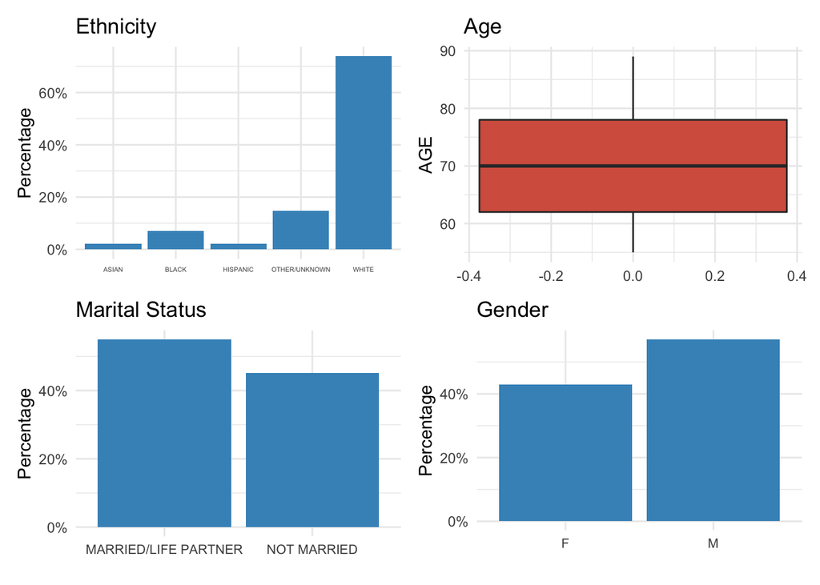

```r
los_total <- ggplot(data = mimic, aes(y=LOS)) +
  geom_boxplot(fill = "#D6604D") +
  labs(title = "Length of Stay") +
  theme_minimal()

# Summary Graphs 1
ggdraw() +
  draw_plot(ethnicity_total, x=0, y=0.5, width = 0.5, height = 0.5)+
  draw_plot(age_total, x=0.5, y=0.5, width = 0.5, height = 0.5)+
  draw_plot(marital_total, x=0, y=0, width = 0.5, height = 0.5)+
  draw_plot(gender_total, x=0.5, y=0, width = 0.5, height = 0.5)+
  theme_minimal()
```

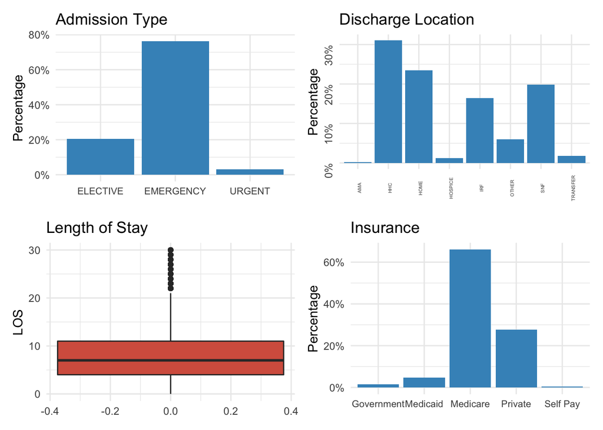

```r
# Summary Graphs 2
ggdraw() +
  draw_plot(admission_total, x=0, y=0.5, width = 0.5, height = 0.5)+ #legend and x labels smaller
  draw_plot(discharge_total, x=0.5, y=0.5, width = 0.5, height = 0.5)+ #same
  draw_plot(los_total, x=0, y=0, width = 0.5, height = 0.5)+
  draw_plot(insurance_total, x=0.5, y=0, width = 0.5, height = 0.5)+ #same
  theme_minimal()
```

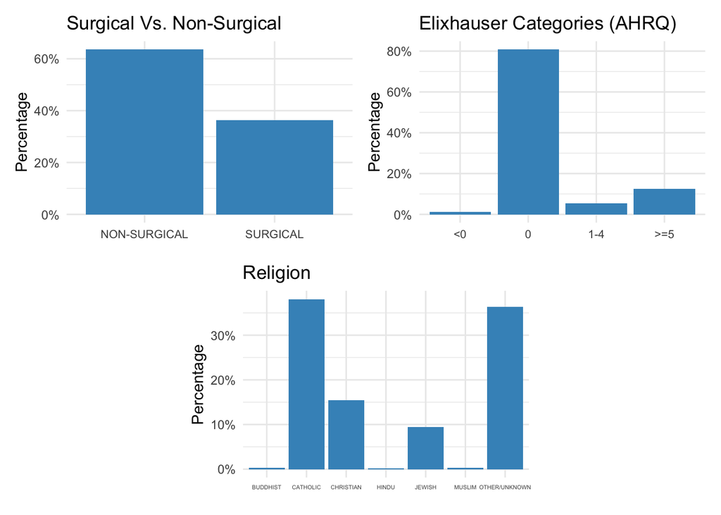

```r
# Summary Graphs 3:
ggdraw() +
  draw_plot(service_total, x=0, y=0.5, width = 0.5, height = .5)+
  draw_plot(elixhauser_total, x=0.5, y=0.5, width=0.5, height=.5)+
  draw_plot(religion_total, x=0.25, y=0, width=0.5, height=0.5)+
  theme_minimal()
```

## Summary Statistics- Between Groups

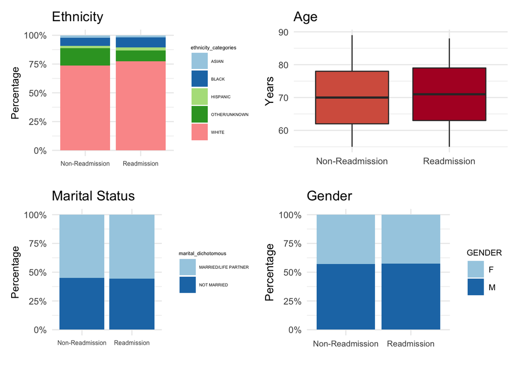

```r
# Summary table (by group)
table2<- tbl_summary(
  mimic_summary,
  by = readmitted_30,
  missing = "no",
) %>%
  add_n() %>%
  modify_header(label = "**Variable**") %>%
  bold_labels() %>%
  italicize_levels()%>%
  add_overall()
table2

# Gender
table(mimic$GENDER, mimic$readmitted_30)

gender_split <- ggplot(data = mimic, aes(x = factor(readmitted_30), fill = GENDER)) +
  geom_bar(position = "fill") +
  scale_y_continuous(labels = scales::percent) +
  ylab("Percentage")+
  xlab("")+
  labs(title = "Gender")+
  scale_fill_brewer(palette="Paired")+
  theme_minimal()+
  theme(axis.text.x = element_text(size=8),
        axis.title.x = element_text(size=8),
        legend.title = element_text(size =8),
        legend.text = element_text(size=8))

# Admission Type
table(mimic$ADMISSION_TYPE, mimic$readmitted_30)

admission_split <- ggplot(data = mimic, aes(x = factor(readmitted_30), fill = ADMISSION_TYPE)) +
  geom_bar(position = "fill") +
  scale_y_continuous(labels = scales::percent) +
  ylab("Percentage")+
  xlab("")+
  labs(title = "Admission Type")+
  scale_fill_brewer(palette="Paired")+
  theme_minimal()+
  theme(axis.text.x = element_text(size=6),
        axis.title.x = element_text(size=10),
        legend.title = element_text(size =5),
        legend.text = element_text(size=4),
        axis.title.y = element_text(size=10))

# Discharge Location
table(mimic$discharge_categories, mimic$readmitted_30)

discharge_split <- ggplot(data = mimic, aes(x = factor(readmitted_30), fill = discharge_categories)) +
  geom_bar(position = "fill") +
  scale_y_continuous(labels = scales::percent) +
  ylab("Percentage")+
  xlab("")+
  labs(title = "Discharge Location")+
  scale_fill_brewer(palette="Paired")+
  theme_minimal()+
  theme(axis.text.x = element_text(size=6),
        axis.title.x = element_text(size=10),
        legend.title = element_text(size =5),
        legend.text = element_text(size=4),
        axis.title.y = element_text(size=10))


# Insurance
table(mimic$INSURANCE, mimic$readmitted_30)

insurance_split<- ggplot(data = mimic, aes(x = factor(readmitted_30), fill = INSURANCE)) +
  geom_bar(position = "fill") +
  scale_y_continuous(labels = scales::percent) +
  ylab("Percentage")+
  xlab("")+
  labs(title = "Insurance")+
  scale_fill_brewer(palette="Paired")+
  theme_minimal()+
  theme(axis.text.x = element_text(size=6),
        axis.title.x = element_text(size=10),
        legend.title = element_text(size =5),
        legend.text = element_text(size=4),
        axis.title.y = element_text(size=10))

# Religion
table(mimic$religion_categories, mimic$readmitted_30)

religion_split<- ggplot(data = mimic, aes(x = factor(readmitted_30), fill = religion_categories)) +
  geom_bar(position = "fill") +
  scale_y_continuous(labels = scales::percent) +
  ylab("Percentage")+
  xlab("")+
  labs(title = "Religion")+
  scale_fill_brewer(palette="Paired")+
  theme_minimal()

# Marital Status
table(mimic$marital_dichotomous, mimic$readmitted_30)

marital_split<- ggplot(data = mimic, aes(x = factor(readmitted_30), fill = marital_dichotomous)) +
  geom_bar(position = "fill") +
  scale_y_continuous(labels = scales::percent) +
  ylab("Percentage")+
  xlab("")+
  labs(title = "Marital Status")+
  scale_fill_brewer(palette="Paired")+
  theme_minimal()+
  theme(axis.text.x = element_text(size=6),
        axis.title.x = element_text(size=10),
        legend.title = element_text(size =5),
        legend.text = element_text(size=4),
        axis.title.y = element_text(size=10))


# Ethnicity
table(mimic$ethnicity_categories, mimic$readmitted_30)

ethnicity_split <- ggplot(data = mimic, aes(x = factor(readmitted_30), fill = ethnicity_categories)) +
  geom_bar(position = "fill") +
  scale_y_continuous(labels = scales::percent) +
  ylab("Percentage")+
  xlab("")+
  labs(title = "Ethnicity")+
  scale_fill_brewer(palette="Paired")+
  theme_minimal()+
  theme(axis.text.x = element_text(size=6),
        axis.title.x = element_text(size=10),
        legend.title = element_text(size =5),
        legend.text = element_text(size=4),
        axis.title.y = element_text(size=10))

# Service
table(mimic$service, mimic$readmitted_30)

service_split <- ggplot(data = mimic, aes(x = factor(readmitted_30), fill = service)) +
  geom_bar(position = "fill") +
  scale_y_continuous(labels = scales::percent) +
  ylab("Percentage")+
  xlab("")+
  labs(title = "Surgical vs. Non-Surgical")+
  scale_fill_brewer(palette="Paired")+
  theme_minimal()+
  theme(axis.text.x = element_text(size=6),
        axis.title.x = element_text(size=10),
        legend.title = element_text(size =5),
        legend.text = element_text(size=4),
        axis.title.y = element_text(size=10))


# Elixhauser Categories
table(mimic$elixhauser_categories, mimic$readmitted_30)

elixhauser_split <- ggplot(data = mimic, aes(x = factor(readmitted_30), fill = elixhauser_categories)) +
  geom_bar(position = "fill") +
  scale_y_continuous(labels = scales::percent) +
  ylab("Percentage")+
  xlab("")+
  labs(title = "Elixhauser Categories")+
  scale_fill_brewer(palette="Paired")+
  theme_minimal()+
  theme(axis.text.x = element_text(size=6),
        axis.title.x = element_text(size=10),
        legend.title = element_text(size =5),
        legend.text = element_text(size=4),
        axis.title.y = element_text(size=10))


# Age
tapply(mimic$AGE, mimic$readmitted_30, summary)

age_split <- ggplot(data = mimic, aes(readmitted_30, AGE)) +
  geom_boxplot(fill=c("#D6604D", "#B2182B")) +
  labs(title = "Age") +
  ylab("Years")+
  xlab("")+
  theme_minimal()

# LOS
tapply(mimic$LOS, mimic$readmitted_30, summary)
los_split <- ggplot(data = mimic, aes(readmitted_30, LOS)) +
  geom_boxplot(fill=c("#D6604D", "#B2182B")) +
  labs(title = "Length of Stay") +
  ylab("Days")+
  xlab("")+
  theme_minimal()

# Summary Graphs 1: Demographics between group comparison
ggdraw() +
  draw_plot(ethnicity_split, x=0, y=0.5, width = 0.5, height = 0.5)+
  draw_plot(age_split, x=0.5, y=0.5, width = 0.5, height = 0.5)+
  draw_plot(marital_split, x=0, y=0, width = 0.5, height = 0.5)+
  draw_plot(gender_split, x=0.5, y=0, width = 0.5, height = 0.5)+
  theme_minimal()
```

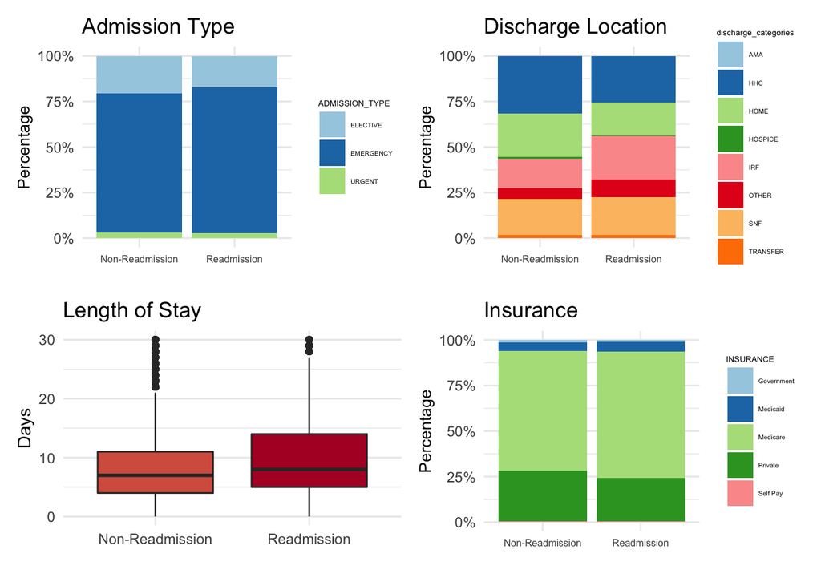

```r
#Summary graphs 2: Clinical between groups comparison
ggdraw() +
  draw_plot(admission_split, x=0, y=0.5, width = 0.5, height = 0.5)+ #legend and x labels smaller
  draw_plot(discharge_split, x=0.5, y=0.5, width = 0.5, height = 0.5)+ #same
  draw_plot(los_split, x=0, y=0, width = 0.5, height = 0.5)+
  draw_plot(insurance_split, x=0.5, y=0, width = 0.5, height = 0.5)+ #same
  theme_minimal()
```

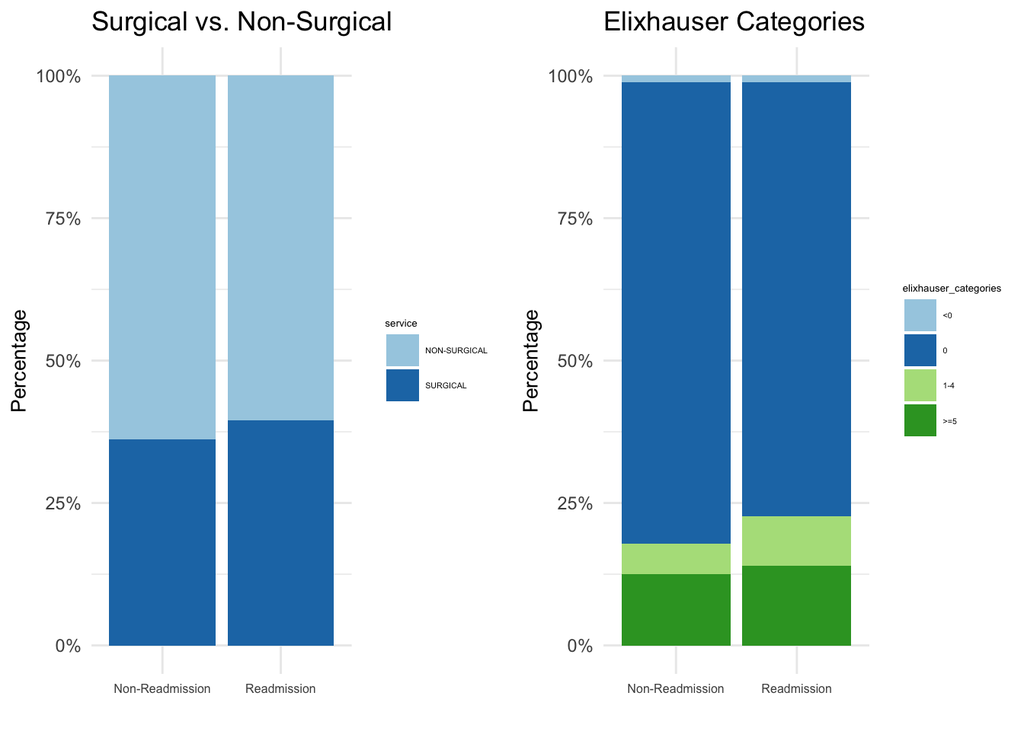

```r
# Summary Graphs 3: More Analysis
ggdraw() +
  draw_plot(service_split, x=0, y=0, width = 0.5, height = 1)+
  draw_plot(elixhauser_split, x=0.5, y=0, width=0.5, height=1)
```

```r
  theme_minimal()
```

## Preliminary Analyses

A series of univariable analyses were conducted to explore clinically significant variables to be incorporated into the final model. Those analyses are included in the kennedy_preliminary_statistics.rmd file. The goal of the univariable analysis was not to eliminate variables (since that could create a high risk of bias), but rather to explore the idea of categorized vs. dichotomized variables. Please see that file in the repository for more detail.

## Initial Multivariable Logistic Model

My initial multivariable logistic regression contained all of the clinically and socially relevant variables (based in the literature and clinical expertise). Some variables were preserved in their initial categories from the raw data (insurance, gender, admission type, age, length of stay), while others were collapsed into smaller categories (discharge disposition, marital status, ethnicity, service type, elixhauser categories).

In this model. Few variables were significant at the 0.05 level. These variables included admission type (emergency admission p=0.001, OR 1.36), surgical population (p=0.002, OR 1.26), and length of stay (p<0.001, OR 1.02). Although these are technically statistically significant, the odds ratios are fairly low and don’t hold much clinical significance.

```r
model1 <- glm(readmitted_30 ~ GENDER + ADMISSION_TYPE + discharge_categories + INSURANCE + marital_dichotomous + ethnicity_categories + service+ elixhauser_categories + AGE + LOS, data = mimic,
                  family = binomial())
summary(model1)
```

```
##
## Call:
## glm(formula = readmitted_30 ~ GENDER + ADMISSION_TYPE + discharge_categories +
##     INSURANCE + marital_dichotomous + ethnicity_categories +
##     service + elixhauser_categories + AGE + LOS, family = binomial(),
##     data = mimic)
##
## Deviance Residuals:
##     Min       1Q   Median       3Q      Max
## -0.6457  -0.3407  -0.2934  -0.2591   3.3116
##
## Coefficients:
##                                    Estimate Std. Error z value Pr(>|z|)
## (Intercept)                       -4.928114   1.146635  -4.298 1.72e-05 ***
## GENDERM                            0.047814   0.065981   0.725  0.46866
## ADMISSION_TYPEEMERGENCY            0.309308   0.096871   3.193  0.00141 **
## ADMISSION_TYPEURGENT               0.322446   0.207996   1.550  0.12108
## discharge_categoriesHHC            0.850835   1.013713   0.839  0.40129
## discharge_categoriesHOME           0.850584   1.013886   0.839  0.40151
## discharge_categoriesHOSPICE       -1.042551   1.236634  -0.843  0.39920
## discharge_categoriesIRF            1.330958   1.015056   1.311  0.18978
## discharge_categoriesOTHER          1.451034   1.017385   1.426  0.15380
## discharge_categoriesSNF            1.026563   1.014990   1.011  0.31182
## discharge_categoriesTRANSFER       1.040036   1.040089   1.000  0.31733
## INSURANCEMedicaid                  0.543059   0.350419   1.550  0.12120
## INSURANCEMedicare                  0.432977   0.331882   1.305  0.19202
## INSURANCEPrivate                   0.254102   0.331139   0.767  0.44287
## INSURANCESelf Pay                  0.587103   0.564287   1.040  0.29814
## marital_dichotomousNOT MARRIED    -0.112103   0.067802  -1.653  0.09825 .
## ethnicity_categoriesBLACK          0.377881   0.250819   1.507  0.13192
## ethnicity_categoriesHISPANIC       0.412214   0.294466   1.400  0.16155
## ethnicity_categoriesOTHER/UNKNOWN -0.374055   0.248678  -1.504  0.13254
## ethnicity_categoriesWHITE          0.185087   0.229050   0.808  0.41905
## serviceSURGICAL                    0.228132   0.074488   3.063  0.00219 **
## elixhauser_categories0            -0.014562   0.301646  -0.048  0.96150
## elixhauser_categories1-4           0.445218   0.318488   1.398  0.16214
## elixhauser_categories>=5           0.204482   0.311109   0.657  0.51101
## AGE                               -0.002421   0.004371  -0.554  0.57962
## LOS                                0.023526   0.005192   4.531 5.87e-06 ***
## ---
## Signif. codes:  0 '***' 0.001 '**' 0.01 '*' 0.05 '.' 0.1 ' ' 1
##
## (Dispersion parameter for binomial family taken to be 1)
##
##     Null deviance: 8669.3  on 22349  degrees of freedom
## Residual deviance: 8458.4  on 22324  degrees of freedom
## AIC: 8510.4
##
## Number of Fisher Scoring iterations: 7
```

```r
exp(cbind(OR = coef(model1), CI = confint(model1))) #OR and 95%CI
```

```
##                                            OR        2.5 %      97.5 %
## (Intercept)                       0.007240144 0.0003551501  0.04815503
## GENDERM                           1.048975627 0.9220044755  1.19422618
## ADMISSION_TYPEEMERGENCY           1.362482562 1.1284806477  1.65000334
## ADMISSION_TYPEURGENT              1.380500958 0.9033367091  2.04655991
## discharge_categoriesHHC           2.341600799 0.5080437377 41.59871004
## discharge_categoriesHOME          2.341014063 0.5075997246 41.59499918
## discharge_categoriesHOSPICE       0.352554259 0.0330235089  7.69119296
## discharge_categoriesIRF           3.784667465 0.8175213464 67.32151004
## discharge_categoriesOTHER         4.267525884 0.9146629426 76.07916684
## discharge_categoriesSNF           2.791455753 0.6030982343 49.65107028
## discharge_categoriesTRANSFER      2.829319805 0.5625180891 51.53916556
## INSURANCEMedicaid                 1.721264709 0.9050062318  3.62675164
## INSURANCEMedicare                 1.541840891 0.8473408885  3.15495083
## INSURANCEPrivate                  1.289303032 0.7097497162  2.63500241
## INSURANCESelf Pay                 1.798769265 0.5453042472  5.23863577
## marital_dichotomousNOT MARRIED    0.893952109 0.7825062980  1.02079548
## ethnicity_categoriesBLACK         1.459189594 0.9102145702  2.44467698
## ethnicity_categoriesHISPANIC      1.510157999 0.8524574340  2.72190369
## ethnicity_categoriesOTHER/UNKNOWN 0.687939137 0.4311469549  1.14830367
## ethnicity_categoriesWHITE         1.203323313 0.7879965517  1.94270398
## serviceSURGICAL                   1.256250852 1.0845706259  1.45243602
## elixhauser_categories0            0.985543942 0.5702538850  1.87974924
## elixhauser_categories1-4          1.560831146 0.8686392161  3.05978295
## elixhauser_categories>=5          1.226889259 0.6945842157  2.37648352
## AGE                               0.997581884 0.9890734764  1.00616562
## LOS                               1.023805203 1.0133672828  1.03420810
```

```r
# Creating a nice summary table
t3 <- tbl_regression(model1, exponentiate = TRUE) %>%
  bold_p(t = 0.10) %>%
  bold_labels() %>%
  italicize_levels()
t3
```

| **Characteristic** | **OR**<sup>1</sup> | **95% CI**<sup>1</sup> | **p-value** |
| --- | --- | --- | --- |
| GENDER |  |  |  |
| F | — | — |  |
| M | 1.05 | 0.92, 1.19 | 0.5 |
| ADMISSION_TYPE |  |  |  |
| ELECTIVE | — | — |  |
| EMERGENCY | 1.36 | 1.13, 1.65 | 0.001 |
| URGENT | 1.38 | 0.90, 2.05 | 0.12 |
| discharge_categories |  |  |  |
| AMA | — | — |  |
| HHC | 2.34 | 0.51, 41.6 | 0.4 |
| HOME | 2.34 | 0.51, 41.6 | 0.4 |
| HOSPICE | 0.35 | 0.03, 7.69 | 0.4 |
| IRF | 3.78 | 0.82, 67.3 | 0.2 |
| OTHER | 4.27 | 0.91, 76.1 | 0.2 |
| SNF | 2.79 | 0.60, 49.7 | 0.3 |
| TRANSFER | 2.83 | 0.56, 51.5 | 0.3 |
| INSURANCE |  |  |  |
| Government | — | — |  |
| Medicaid | 1.72 | 0.91, 3.63 | 0.12 |
| Medicare | 1.54 | 0.85, 3.15 | 0.2 |
| Private | 1.29 | 0.71, 2.64 | 0.4 |
| Self Pay | 1.80 | 0.55, 5.24 | 0.3 |
| marital_dichotomous |  |  |  |
| MARRIED/LIFE PARTNER | — | — |  |
| NOT MARRIED | 0.89 | 0.78, 1.02 | 0.10 |
| ethnicity_categories |  |  |  |
| ASIAN | — | — |  |
| BLACK | 1.46 | 0.91, 2.44 | 0.13 |
| HISPANIC | 1.51 | 0.85, 2.72 | 0.2 |
| OTHER/UNKNOWN | 0.69 | 0.43, 1.15 | 0.13 |
| WHITE | 1.20 | 0.79, 1.94 | 0.4 |
| service |  |  |  |
| NON-SURGICAL | — | — |  |
| SURGICAL | 1.26 | 1.08, 1.45 | 0.002 |
| elixhauser_categories |  |  |  |
| <0 | — | — |  |
| 0 | 0.99 | 0.57, 1.88 | >0.9 |
| 1-4 | 1.56 | 0.87, 3.06 | 0.2 |
| >=5 | 1.23 | 0.69, 2.38 | 0.5 |
| AGE | 1.00 | 0.99, 1.01 | 0.6 |
| LOS | 1.02 | 1.01, 1.03 | <0.001 |

<sup>*1*</sup> OR = Odds Ratio, CI = Confidence Interval

## Final Logistic Regression Results

Next, we will create a logistic regression model with the dichotomized (final) variables. First, we will do another summary table to compare between the dichotomized groups. There are some statistically significant difference between groups- this is a limitation of the study. Those variables include: admission type (p=0.007), discharge location (p<0.001), insurance categories (p=0.014), ethnicity (p=0.005), surgical population (p=0.03), elixhauser score (p<0.001), and length of stay (p<0.001).

```r
mimic_regression_summary <- mimic %>%
  select(readmitted_30, GENDER, admission_dichotomous, discharge_dichotomous, insurance_categories, marital_dichotomous, ethnicity_dichotomous, service, elixhauser_dichotomous, age_dichotomous, los_dichotomous)

table3<- tbl_summary(
  mimic_regression_summary,
  by = readmitted_30,
  missing = "no",
) %>%
  add_n() %>%
  modify_header(label = "**Variable**") %>%
  bold_labels() %>%
  italicize_levels()%>%
  add_p() %>%
  bold_p() %>%
  add_overall()
table3
```

| **Variable** | **Overall**, N = 22,350<sup>1</sup> | **N** | **Non-Readmission**, N = 21,267<sup>1</sup> | **Readmission**, N = 1,083<sup>1</sup> | **p-value**<sup>2</sup> |
| --- | --- | --- | --- | --- | --- |
| GENDER |  | 22,350 |  |  | 0.9 |
| F | 9,590 (43%) |  | 9,128 (43%) | 462 (43%) |  |
| M | 12,760 (57%) |  | 12,139 (57%) | 621 (57%) |  |
| admission_dichotomous |  | 22,350 |  |  | 0.007 |
| ELECTIVE | 4,595 (21%) |  | 4,408 (21%) | 187 (17%) |  |
| EMERGENCY/URGENT | 17,755 (79%) |  | 16,859 (79%) | 896 (83%) |  |
| discharge_dichotomous |  | 22,350 |  |  | <0.001 |
| HOME | 12,171 (54%) |  | 11,699 (55%) | 472 (44%) |  |
| NON-HOME | 10,179 (46%) |  | 9,568 (45%) | 611 (56%) |  |
| insurance_categories |  | 22,350 |  |  | 0.014 |
| Private | 6,164 (28%) |  | 5,906 (28%) | 258 (24%) |  |
| Public | 16,092 (72%) |  | 15,272 (72%) | 820 (76%) |  |
| Self Pay | 94 (0.4%) |  | 89 (0.4%) | 5 (0.5%) |  |
| marital_dichotomous |  | 22,350 |  |  | 0.7 |
| MARRIED/LIFE PARTNER | 12,270 (55%) |  | 11,669 (55%) | 601 (55%) |  |
| NOT MARRIED | 10,080 (45%) |  | 9,598 (45%) | 482 (45%) |  |
| ethnicity_dichotomous |  | 22,350 |  |  | 0.005 |
| NON-WHITE | 5,844 (26%) |  | 5,601 (26%) | 243 (22%) |  |
| WHITE | 16,506 (74%) |  | 15,666 (74%) | 840 (78%) |  |
| service |  | 22,350 |  |  | 0.030 |
| NON-SURGICAL | 14,220 (64%) |  | 13,565 (64%) | 655 (60%) |  |
| SURGICAL | 8,130 (36%) |  | 7,702 (36%) | 428 (40%) |  |
| elixhauser_dichotomous |  | 22,350 |  |  | <0.001 |
| zero_or_less | 18,317 (82%) |  | 17,480 (82%) | 837 (77%) |  |
| one_or_more | 4,033 (18%) |  | 3,787 (18%) | 246 (23%) |  |
| age_dichotomous |  | 22,350 |  |  | 0.5 |
| (54,70] | 11,271 (50%) |  | 10,735 (50%) | 536 (49%) |  |
| (70,89] | 11,079 (50%) |  | 10,532 (50%) | 547 (51%) |  |
| los_dichotomous |  | 22,350 |  |  | <0.001 |
| (-Inf,7] | 12,055 (54%) |  | 11,570 (54%) | 485 (45%) |  |
| (7,30] | 10,295 (46%) |  | 9,697 (46%) | 598 (55%) |  |

<sup>*1*</sup> Statistics presented: n (%) <sup>*2*</sup> Statistical tests performed: chi-square test of independence; Fisher's exact test

Then, we will create a logistic regression model of the dichotomized variables. Significant variables included emergency/urgent admission (p<0.001, OR 1.43- 95%CI 1.19-1.73), non-home discharge disposition (p<0.001, OR 1.47- 95% CI 1.28-1.68), public insurance (p=0.015, OR 1.22- 95% CI 1.04-1.44), white ethnicity (p=0.005, OR 1.24- 95% CI 1.07-1.43), elixhauser comorbidity score >=1 (p<0.001, OR 1.36- 95% CI 1.17-1.57), and length of stay >7 days (p<0.001, OR 1.25- 95%CI 1.10-1.42).

```r
model2 <- glm(readmitted_30 ~ GENDER + admission_dichotomous + discharge_dichotomous + insurance_categories + marital_dichotomous + ethnicity_dichotomous + service + elixhauser_dichotomous+ age_dichotomous + los_dichotomous, data = mimic,
                  family = binomial())
summary(model2)
```

```
##
## Call:
## glm(formula = readmitted_30 ~ GENDER + admission_dichotomous +
##     discharge_dichotomous + insurance_categories + marital_dichotomous +
##     ethnicity_dichotomous + service + elixhauser_dichotomous +
##     age_dichotomous + los_dichotomous, family = binomial(), data = mimic)
##
## Deviance Residuals:
##     Min       1Q   Median       3Q      Max
## -0.5113  -0.3420  -0.3030  -0.2642   2.8026
##
## Coefficients:
##                                       Estimate Std. Error z value Pr(>|z|)
## (Intercept)                           -3.95063    0.14203 -27.816  < 2e-16 ***
## GENDERM                                0.04335    0.06567   0.660 0.509118
## admission_dichotomousEMERGENCY/URGENT  0.35818    0.09539   3.755 0.000173 ***
## discharge_dichotomousNON-HOME          0.38204    0.07014   5.447 5.12e-08 ***
## insurance_categoriesPublic             0.20258    0.08353   2.425 0.015300 *
## insurance_categoriesSelf Pay           0.37456    0.46625   0.803 0.421771
## marital_dichotomousNOT MARRIED        -0.11003    0.06681  -1.647 0.099586 .
## ethnicity_dichotomousWHITE             0.21136    0.07507   2.815 0.004872 **
## serviceSURGICAL                        0.25622    0.07312   3.504 0.000458 ***
## elixhauser_dichotomousone_or_more      0.30515    0.07576   4.028 5.63e-05 ***
## age_dichotomous(70,89]                -0.13587    0.07138  -1.904 0.056968 .
## los_dichotomous(7,30]                  0.22294    0.06647   3.354 0.000797 ***
## ---
## Signif. codes:  0 '***' 0.001 '**' 0.01 '*' 0.05 '.' 0.1 ' ' 1
##
## (Dispersion parameter for binomial family taken to be 1)
##
##     Null deviance: 8669.3  on 22349  degrees of freedom
## Residual deviance: 8548.8  on 22338  degrees of freedom
## AIC: 8572.8
##
## Number of Fisher Scoring iterations: 6
```

```r
exp(cbind(OR = coef(model1), CI = confint(model1))) #OR and 95%CI
```

```
##                                            OR        2.5 %      97.5 %
## (Intercept)                       0.007240144 0.0003551501  0.04815503
## GENDERM                           1.048975627 0.9220044755  1.19422618
## ADMISSION_TYPEEMERGENCY           1.362482562 1.1284806477  1.65000334
## ADMISSION_TYPEURGENT              1.380500958 0.9033367091  2.04655991
## discharge_categoriesHHC           2.341600799 0.5080437377 41.59871004
## discharge_categoriesHOME          2.341014063 0.5075997246 41.59499918
## discharge_categoriesHOSPICE       0.352554259 0.0330235089  7.69119296
## discharge_categoriesIRF           3.784667465 0.8175213464 67.32151004
## discharge_categoriesOTHER         4.267525884 0.9146629426 76.07916684
## discharge_categoriesSNF           2.791455753 0.6030982343 49.65107028
## discharge_categoriesTRANSFER      2.829319805 0.5625180891 51.53916556
## INSURANCEMedicaid                 1.721264709 0.9050062318  3.62675164
## INSURANCEMedicare                 1.541840891 0.8473408885  3.15495083
## INSURANCEPrivate                  1.289303032 0.7097497162  2.63500241
## INSURANCESelf Pay                 1.798769265 0.5453042472  5.23863577
## marital_dichotomousNOT MARRIED    0.893952109 0.7825062980  1.02079548
## ethnicity_categoriesBLACK         1.459189594 0.9102145702  2.44467698
## ethnicity_categoriesHISPANIC      1.510157999 0.8524574340  2.72190369
## ethnicity_categoriesOTHER/UNKNOWN 0.687939137 0.4311469549  1.14830367
## ethnicity_categoriesWHITE         1.203323313 0.7879965517  1.94270398
## serviceSURGICAL                   1.256250852 1.0845706259  1.45243602
## elixhauser_categories0            0.985543942 0.5702538850  1.87974924
## elixhauser_categories1-4          1.560831146 0.8686392161  3.05978295
## elixhauser_categories>=5          1.226889259 0.6945842157  2.37648352
## AGE                               0.997581884 0.9890734764  1.00616562
## LOS                               1.023805203 1.0133672828  1.03420810
```

```r
# Creating a nice summary table for better visualization
t4 <- tbl_regression(model2, exponentiate = TRUE) %>%
  bold_p(t = 0.10) %>%
  bold_labels() %>%
  italicize_levels()
t4
```

| **Characteristic** | **OR**<sup>1</sup> | **95% CI**<sup>1</sup> | **p-value** |
| --- | --- | --- | --- |
| GENDER |  |  |  |
| F | — | — |  |
| M | 1.04 | 0.92, 1.19 | 0.5 |
| admission_dichotomous |  |  |  |
| ELECTIVE | — | — |  |
| EMERGENCY/URGENT | 1.43 | 1.19, 1.73 | <0.001 |
| discharge_dichotomous |  |  |  |
| HOME | — | — |  |
| NON-HOME | 1.47 | 1.28, 1.68 | <0.001 |
| insurance_categories |  |  |  |
| Private | — | — |  |
| Public | 1.22 | 1.04, 1.44 | 0.015 |
| Self Pay | 1.45 | 0.51, 3.28 | 0.4 |
| marital_dichotomous |  |  |  |
| MARRIED/LIFE PARTNER | — | — |  |
| NOT MARRIED | 0.90 | 0.79, 1.02 | 0.10 |
| ethnicity_dichotomous |  |  |  |
| NON-WHITE | — | — |  |
| WHITE | 1.24 | 1.07, 1.43 | 0.005 |
| service |  |  |  |
| NON-SURGICAL | — | — |  |
| SURGICAL | 1.29 | 1.12, 1.49 | <0.001 |
| elixhauser_dichotomous |  |  |  |
| zero_or_less | — | — |  |
| one_or_more | 1.36 | 1.17, 1.57 | <0.001 |
| age_dichotomous |  |  |  |
| (54,70] | — | — |  |
| (70,89] | 0.87 | 0.76, 1.00 | 0.057 |
| los_dichotomous |  |  |  |
| (-Inf,7] | — | — |  |
| (7,30] | 1.25 | 1.10, 1.42 | <0.001 |

<sup>*1*</sup> OR = Odds Ratio, CI = Confidence Interval

## Cross Validation Procedure

Next, I cross-validated the logistic model as a form of internal validation. I used k-fold sampling with 10 folds. Model performance on the training and testing datasets are included in the next section.

```r
glm.pred <- predict(model2, mimic, type = "response")
head(glm.pred)
```

```
##          1          2          3          4          5          6
## 0.08242581 0.05995193 0.02857100 0.06500653 0.04746857 0.03315011
```

```r
#K Fold Cross Validation
N = nrow(mimic)
K = 10
set.seed(48585)
s = sample(1:K, size = N, replace = T)
pred.outputs.glm <- vector(mode = "numeric", length = N)
obs.outputs <- vector(mode = "numeric", length = N)
offset<- 0

for (i in 1:K){
  train <- filter(mimic, s != i)
  test <- filter(mimic, s == i)
  obs.outputs[1:length(s[s == i]) + offset] <- test$readmitted_30

  # GLM train/test
  glm <- glm(readmitted_30 ~ GENDER + admission_dichotomous + discharge_dichotomous + insurance_categories + marital_dichotomous + ethnicity_dichotomous + service + elixhauser_dichotomous+ age_dichotomous + los_dichotomous, data = train, family = binomial(logit))
  glm.pred.curr <- predict(glm, test, type = "response")
  pred.outputs.glm[1:length(s[s == i]) + offset] <- glm.pred.curr

  offset <- offset + length(s[s == i])
}
head(cbind(pred.outputs.glm, obs.outputs))
```

```
##      pred.outputs.glm obs.outputs
## [1,]       0.02879587           1
## [2,]       0.03251026           1
## [3,]       0.04936432           1
## [4,]       0.05262780           1
## [5,]       0.03610281           1
## [6,]       0.03094974           1
```

## Model Performance: Area Under the Curve

As we can see from the AUC calculations and the ROC curve, the logistic model demonstrated poor performance. AUC in the training datset was 59.8% and AUC in the testing dataset was only 58.9%. This is marginally better than a coin flip.

```r
roc(mimic$readmitted_30, glm.pred, ci = TRUE) #predicted data, ci is confidence interviews
```

```
##
## Call:
## roc.default(response = mimic$readmitted_30, predictor = glm.pred,     ci = TRUE)
##
## Data: glm.pred in 21267 controls (mimic$readmitted_30 Non-Readmission) < 1083 cases (mimic$readmitted_30 Readmission).
## Area under the curve: 0.5979
## 95% CI: 0.5809-0.6149 (DeLong)
```

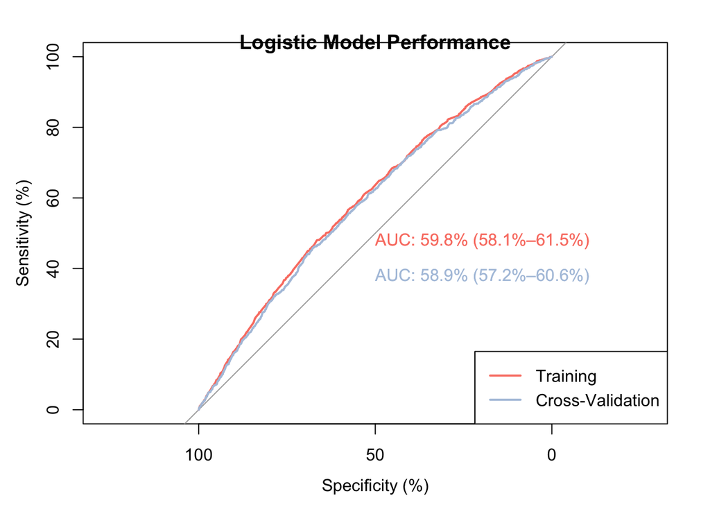

```r
plot.roc(mimic$readmitted_30, glm.pred, percent = TRUE, col = "salmon", print.auc= TRUE, ci = TRUE) #graph that corresponds to that
plot.roc(obs.outputs, pred.outputs.glm, percent = TRUE, print.auc = TRUE, print.auc.y = 40, ci = TRUE, col = "lightsteelblue", add = TRUE) #observed data. cross validation curve is almost the same
legend("bottomright", legend = c("Training", "Cross-Validation"), col = c("salmon", "lightsteelblue"), lwd = 2)
title(main="Logistic Model Performance")
```

# Conclusion

Our final sample included 22,350 ICU patients, with a 4.8% 30-day readmission rate. This unbalanced sample is a limitation of the study that is often encountered in similar studies (Zhou et al, 2016). Nearly half of the readmission cohort was readmitted within the first 7 days of discharge. Usually readmissions within this time frame could indicate that the patient was not ready for discharge, and readmissions within this time frame are considered to be more preventable than later readmissions (Graham et al, 2018). My goal was to build a model focused on clinical and social factors based in the literature from previous systematic reviews (Zhou et al, 2016). All variables initially selected for clinical relevance were maintained in the final models in order to reduce potential bias, but I did dichotomize variables for the final model to improve performance which is a limitation.

# References

Bailey, M. K., Weiss, A. J., Barret, M. L., & Jiang, H. J. (2019). Statistical Brief #248: Characteristics of 30-Day All-Cause Hospital Readmissions, 2010-2016. Retrieved from https://www.hcup-us.ahrq.gov/reports/statbriefs/sb248-Hospital-Readmissions-2010-2016.pdf

BBC (2020). BBPlot. Github Repository. Retrieved from https://github.com/bbc/bbplot/.

Bradley, E. H., Sipsma, H., Horwitz, L. I., Curry, L., & Krumholz, H. M. (2014). Contemporary Data About Hospital Strategies to Reduce Unplanned Readmissions: What Has Changed? JAMA Internal Medicine, 174(1), 154-156. doi:10.1001/jamainternmed.2013.11574

Graham, K. L., Auerbach, A. D., Schnipper, J. L., Flanders, S. A., Kim, C. S., Robinson, E. J., Ruhnke, G. W., Thomas, L. R., Kripalani, S., Vasilevskis, E. E., Fletcher, G. S., Sehgal, N. J., Lindenauer, P. K., Williams, M. V., Metlay, J. P., Davis, R. B., Yang, J., Marcantonio, E. R., & Herzig, S. J. (2018). Preventability of Early Versus Late Hospital Readmissions in a National Cohort of General Medicine Patients. Annals of internal medicine, 168(11), 766–774. https://doi.org/10.7326/M17-1724

Healthy People 2020. (2020). Social Determinants of Health. Retrieved from https://www.healthypeople.gov/2020/topics-objectives/topic/social-determinants-of-health

McDermott, K. W., & Jiang, H. J. (2020). Characteristics and Costs of Potentially Preventable Inpatient Stays, 2017. Retrieved from https://www.hcup-us.ahrq.gov/reports/statbriefs/sb259-Potentially-Preventable-Hospitalizations-2017.pdf

Menendez, M. E., Neuhaus, V., van Dijk, C. N., & Ring, D. (2014). The Elixhauser comorbidity method outperforms the Charlson index in predicting inpatient death after orthopaedic surgery. Clinical orthopaedics and related research, 472(9), 2878–2886. https://doi.org/10.1007/s11999-014-3686-7

Moore, B. J., White, S., Washington, R., Coenen, N., & Elixhauser, A. (2017). Identifying Increased Risk of Readmission and In-hospital Mortality Using Hospital Administrative Data: The AHRQ Elixhauser Comorbidity Index. Medical care, 55(7), 698–705. https://doi.org/10.1097/MLR.0000000000000735

MIMIC-III, a freely accessible critical care database. Johnson AEW, Pollard TJ, Shen L, Lehman L, Feng M, Ghassemi M, Moody B, Szolovits P, Celi LA, and Mark RG. Scientific Data (2016). DOI: 10.1038/sdata.2016.35. Available from: http://www.nature.com/articles/sdata201635

Pollack, R. (2019). Perspective: Post-acute care is a vital part of health care delibery. Retrieved from https://www.aha.org/news/perspective/2019-07-12-perspective-post-acute-care-vital-part-health-care-delivery

Prusaczyk, B., Kripalani, S., & Dhand, A. (2019). Networks of hospital discharge planning teams and readmissions. Journal of Interprofessional Care, 33(1), 85-92. doi:10.1080/13561820.2018.1515193

Rojas, J. C., Carey, K. A., Edelson, D. P., Venable, L. R., Howell, M. D., & Churpek, M. M. (2018). Predicting Intensive Care Unit Readmission with Machine Learning Using Electronic Health Record Data. Annals of the American Thoracic Society, 15(7), 846–853. https://doi.org/10.1513/AnnalsATS.201710-787OC

Xue, Y., Klabjan, D., & Luo, Y. (2019). Predicting ICU readmission using grouped physiological and medication trends. Artificial intelligence in medicine, 95, 27–37. https://doi.org/10.1016/j.artmed.2018.08.004

Zhou, H., Della, P. R., Roberts, P., Goh, L., & Dhaliwal, S. S. (2016). Utility of models to predict 28-day or 30-day unplanned hospital readmissions: an updated systematic review. BMJ Open, 6(6), e011060. doi:10.1136/bmjopen-2016-011060